```python
import os
import pandas as pd
import numpy as np
import matplotlib.pyplot as plt
import matplotlib.pyplot as plt
import locale
from matplotlib.ticker import (MultipleLocator, FormatStrFormatter,
                               AutoMinorLocator)

locale.setlocale(locale.LC_ALL, 'en_US')
from datetime import datetime
import seaborn as sns

import os
import pandas as pd
import numpy as np
import matplotlib.pyplot as plt
import matplotlib.pyplot as plt
import locale
from matplotlib.ticker import (MultipleLocator, FormatStrFormatter,
                               AutoMinorLocator)
from sklearn.model_selection import train_test_split
from sklearn.ensemble import RandomForestClassifier
locale.setlocale(locale.LC_ALL, 'en_US')
from datetime import datetime
from sklearn.metrics import accuracy_score
from sklearn.metrics import roc_auc_score
```

# Chapter1: Exploratory Data Analysis

## Read Data

```python
data = pd.read_csv('Data/train.csv')
def missing_values_table(df):
        # Total missing values
        mis_val = df.isnull().sum()

        # Percentage of missing values
        mis_val_percent = 100 * df.isnull().sum() / len(df)

        # Make a table with the results
        mis_val_table = pd.concat([mis_val, mis_val_percent], axis=1)

        # Rename the columns
        mis_val_table_ren_columns = mis_val_table.rename(
        columns = {0 : 'Missing Values', 1 : '% of Total Values'})

        # Sort the table by percentage of missing descending
        mis_val_table_ren_columns = mis_val_table_ren_columns[
            mis_val_table_ren_columns.iloc[:,1] != 0].sort_values(
        '% of Total Values', ascending=False).round(1)

        # Print some summary information
        print ("Your selected dataframe has " + str(df.shape[1]) + " columns.\n"
            "There are " + str(mis_val_table_ren_columns.shape[0]) +
              " columns that have missing values.")

        # Return the dataframe with missing information
        return mis_val_table_ren_columns
missing_values_table(data)
```

```
Your selected dataframe has 13 columns.
There are 1 columns that have missing values.
```

|  | Missing Values | % of Total Values |
| --- | --- | --- |
| industry | 1 | 0.0 |

```python
data.head()
```

|  | id | industry | state | request_date | term | employee_count | business_new | business_type | location | other_loans | loan_amount | insured_amount | default_status |
| --- | --- | --- | --- | --- | --- | --- | --- | --- | --- | --- | --- | --- | --- |
| 0 | 4050975007 | Others | VA | 27-Apr-10 | 34 | 4 | New | 0 | Rural | N | $35,000.00 | $35,000.00 | 1 |
| 1 | 3735095001 | Manufacturing | CA | 05-Nov-09 | 107 | 1 | New | 0 | Rural | N | $15,000.00 | $13,500.00 | 1 |
| 2 | 3936555004 | Trading | CA | 26-Feb-10 | 84 | 1 | New | 0 | Rural | Y | $265,000.00 | $100,000.00 | 0 |
| 3 | 4130405000 | Engineering | MI | 10-Jun-10 | 240 | 21 | New | 0 | Rural | N | $255,000.00 | $255,000.00 | 0 |
| 4 | 4263615008 | Education | NH | 23-Sep-10 | 36 | 1 | Existing | 0 | Rural | N | $13,300.00 | $6,650.00 | 0 |

## Data Cleaning & Feature Engineering

```python
data['insured_amount'] =data['insured_amount'].str.replace(',','')
data['insured_amount'] = data['insured_amount'].str.replace('$','')
data['loan_amount'] = data['loan_amount'].str.replace('$','')
data['loan_amount'] = data['loan_amount'].str.replace(',','')
data['industry'] = data['industry'].fillna('unknown')
data['ones'] = np.ones(data.shape[0])
data['loan_amount'] = data['loan_amount'].astype('float32')
data['insured_amount'] = data['insured_amount'].astype('float32')
```

create month and year features from request_date

```python
data['request_date'] = data['request_date'].apply(lambda x: datetime.strptime(x,'%d-%b-%y').date())
data['month'] = data['request_date'].apply(lambda x: x.month)
data['year'] = data['request_date'].apply(lambda x: x.year)
data['ones'] = np.ones(data.shape[0])
```

## Univariate Analysis

The target data is imbalanced but the population of minority class is sufficient at 32 percent. Thus there is no need to use upsampling methods on minority class

```python
data['default_status'].value_counts(normalize=True)
```

```
0    0.678185
1    0.321815
Name: default_status, dtype: float64
```

### Univariate Analysis:Categorical Variables

The pie charts given below plot the frequency of occurence of different categories for categorical variables

```python
def plot_pie_num(data,x,s):
    grouped_data = data.groupby([str(x)]).agg({'ones':'sum'})/data.shape[0]*100
    grouped_data2 = grouped_data.reset_index()
    grouped_data2.rename({'ones':'frequency'},inplace = True, axis = 1)
    #plotting default ratios
    fig1, ax1 =plt.subplots(figsize=s)
    ax1.pie(grouped_data2['frequency'],labels= grouped_data2[str(x)] , autopct='%1.1f%%',
        shadow=True, startangle=90)# Equal aspect ratio ensures that pie is drawn as a circle
    ax1.axis('equal')
    plt.tight_layout()
    plt.title(str(x)+" frequency",fontweight = "bold")
```

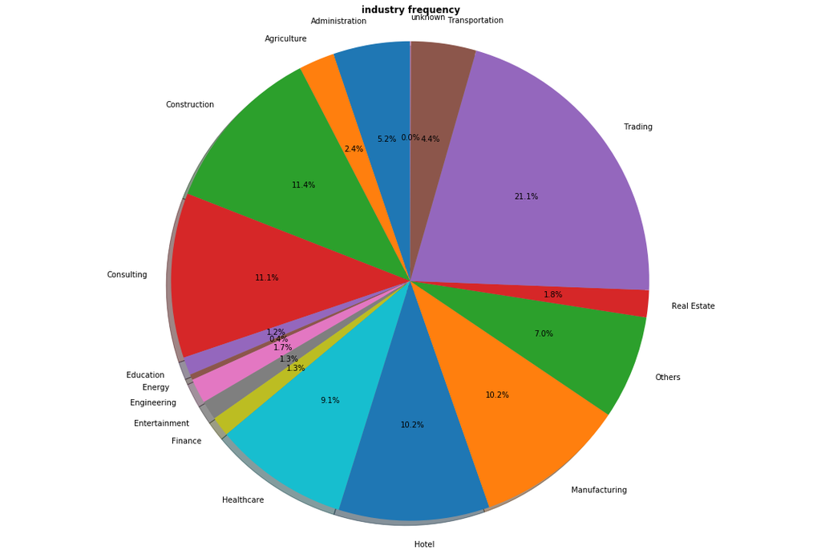

```python
plot_pie_num(data,'industry',(15,10))
```

```
New         0.702331
Existing    0.297669
Name: business_new, dtype: float64
```

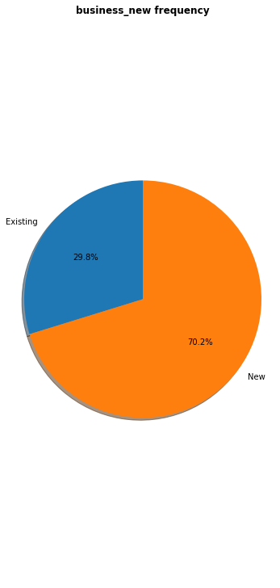

```python
plot_pie_num(data,'business_new',(5,10))
print(data['business_new'].value_counts(normalize=True))
```

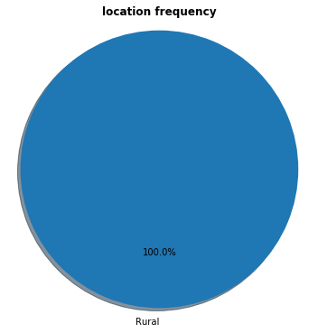

```python
plot_pie_num(data,'location',(5,5))
```

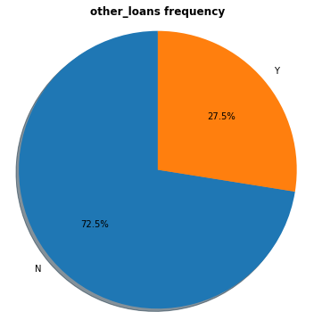

```python
plot_pie_num(data,'other_loans',(5,5))
```

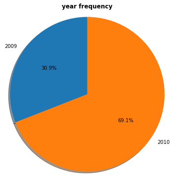

```python
plot_pie_num(data,'year',(5,5))
```

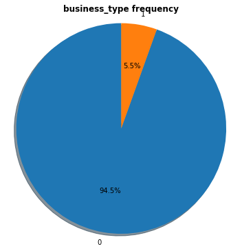

```python
plot_pie_num(data,'business_type',(5,5))
```

#### Univariate Analysis of Continuous variables

The distributions of the continuous variables are plotted below

#### loan_amount

Loan amount has a right-skewed distribution as can be seen below

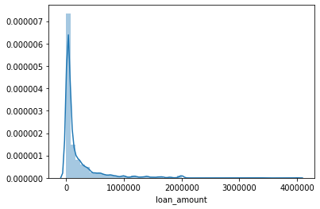

```python
sns.distplot(data['loan_amount'])
```

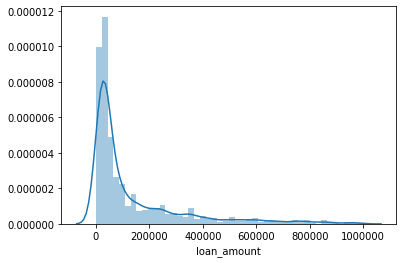

```python
sns.distplot(data[data['loan_amount']<1000000.0]['loan_amount'])
```

#### Insured_amount

Insured amount has a right skewed long tailed distribution (poisson/gamma)

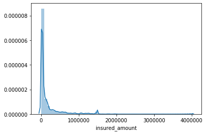

```python
sns.distplot(data['insured_amount'])
```

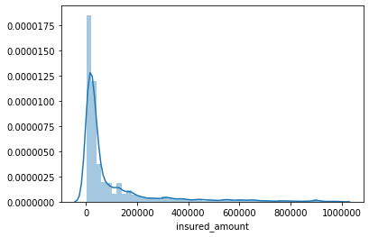

```python
sns.distplot(data[data['insured_amount']<1000000.0]['insured_amount'])
```

#### Term

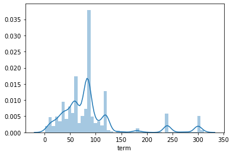

```python
sns.distplot(data['term'])
```

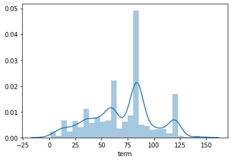

```python
sns.distplot(data[data['term']<150]['term'])
```

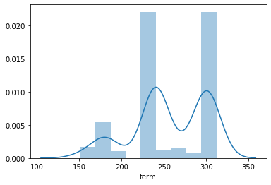

```python
sns.distplot(data[data['term']>150]['term'])
```

#### Employee Count

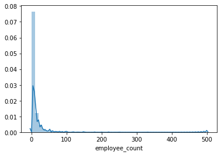

```python
sns.distplot(data['employee_count'])
```

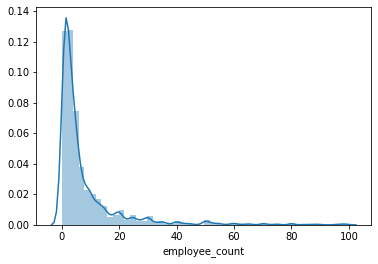

```python
sns.distplot(data[data['employee_count']<100]['employee_count'])
```

### Bi-Variate Analysis

In these set of Plots, we try to establish relationship between variables and the target:default_status

```python
def plot_hist1(data,x,bins,s,LL,UL):
    #x = 'discount'
    def percen(i):
        return(float("{0:.2f}".format(100*i)))
    bin_var = x+'_binned'
    bin_var2 = x+'_binned2'
    data[bin_var] = pd.cut(data[x], bins,right = False)
    data['ones']=np.ones((data.shape[0]))
    data = data.loc[(data[x]>=LL) & (data[x]<=UL)]
    df_dis = data.groupby([bin_var]).agg({'default_status':'sum','ones':'count'}).sort_index()
    df_dis.rename({'default_status':'defaulted'}, inplace = True,axis = 1)
    df_dis2 = df_dis.reset_index()
    df_dis2[bin_var2] = df_dis2[bin_var].apply(lambda x: str(x))
    df_dis2['not_defaulted'] = df_dis2['ones'] - df_dis2['defaulted']
    df_dis2['avg_default_ratio'] = df_dis2['defaulted']/df_dis2['ones']
    df_dis2['avg_non_default_ratio'] = 1 - (df_dis2['defaulted']/df_dis2['ones'])
    #-------------------------------------------------------------------------------------
    plt.figure(figsize = s)
    ax0 = plt.axes()
    bars1 = np.array(df_dis2['defaulted'])
    bars2 = np.array(df_dis2['not_defaulted'])
    bars4 = np.hstack((bars1,bars2))
    bars5 = [locale.format("%d", i, grouping=True) for i in bars4]

    height = 0.25*(bins[1] - bins[0])
    midpoints = [i+0.5*height for i in bins][:-1]
    r1 = [i- 0.5*height for i in midpoints ]
    r2 = [i + 0.5*height for i in midpoints]
    r4 = r1 +r2
    labels = np.array(df_dis2[bin_var2])
    plt.barh(r1, bars1,height = height,color = (1,0.5,0.5,1),label ='Number defaulted')
    plt.barh(r2, bars2,height = height,label ='Number not defaulted')
    plt.xlabel('Count',fontsize = 12)
    plt.ylabel(x,fontsize = 12)
    plt.yticks(midpoints,labels)
    plt.title('Count vs '+x)
    a1 =np.linspace(0,np.ceil(np.max(bars4)/100)*100,11)
    plt.xticks(a1,[locale.format("%d", i, grouping=True) for i in a1])
    #plt.yticks(bins)
    for i in range(len(r4)):
        plt.text(y = r4[i]-0.5*height , x = bars4[i]+0.15, s = bars5[i], size = 8)
    #plt.tick_params(axis='x', which='minor', bottom=False)
    plt.grid(b=True, which='major', axis='x', color='#666666', linestyle='--', linewidth=1,alpha = 0.5)
    plt.legend()
    plt.show()
    #return df_dis2
#---------------------------------------------------------------------

    plt.figure(figsize = s)
    ax0 = plt.axes()
    bars2_1 = np.array(df_dis2['avg_default_ratio'])
    bars2_2 = np.array(df_dis2['avg_non_default_ratio'])
    bars2_4 = np.hstack((bars2_1,bars2_2))
    bars2_5 = [percen(i) for i in bars2_4]
    height = 0.25*(bins[1] - bins[0])
    midpoints = [i+0.5*height for i in bins][:-1]
    r2_1 = [i- 0.5*height for i in midpoints ]
    r2_2 = [i + 0.5*height for i in midpoints]

    r2_4 = r2_1 +r2_2

    labels = np.array(df_dis2[bin_var2])
    plt.barh(r2_1, bars2_1,height = height,color = (1,0.5,0.5,1),label ='percentage defaulted')
    plt.barh(r2_2, bars2_2,height = height,label ='percentage not defaulted')
    plt.xlabel('%defaulted/not-defaulted',fontsize = 12)
    plt.ylabel(x,fontsize = 12)
    plt.yticks(midpoints,labels)
    plt.title('percentage vs '+x)
    a1 = np.linspace(0,1,11)
    plt.xticks(a1,[percen(i) for i in a1])
    for i in range(len(r2_4)):
        plt.text(y = r2_4[i]-0.5*height , x = bars2_4[i]+0.005, s = bars2_5[i], size = 8)
    #plt.tick_params(axis='x', which='minor', bottom=False)
    plt.grid(b=True, which='major', axis='x', color='#666666', linestyle='--', linewidth=1,alpha = 0.5)
    plt.legend()
    plt.show()
    #return df_dis2
#---------------------------------------------------------------------

    plt.figure(figsize = s)
    ax0 = plt.axes()
    bars2_1 = np.array(df_dis2['avg_default_ratio'])
    bars2_2 = np.array(df_dis2['avg_non_default_ratio'])
    bars2_4 = np.hstack((bars2_1,bars2_2))
    bars2_5 = [percen(i) for i in bars2_4]
    height = 0.25*(bins[1] - bins[0])
    midpoints = [i+0.5*height for i in bins][:-1]
    r2_1 = [i- 0.5*height for i in midpoints ]
    r2_2 = [i + 0.5*height for i in midpoints]

    r2_4 = r2_1 +r2_2

    labels = np.array(df_dis2[bin_var2])
    plt.barh(r2_1, bars2_1,height = height,color = (1,0.5,0.5,1),label ='percentage defaulted')
    plt.barh(r2_2, bars2_2,height = height,label ='percentage not defaulted')
    plt.xlabel('%defaulted',fontsize = 12)
    plt.ylabel(x,fontsize = 12)
    plt.yticks(midpoints,labels)
    plt.title('percentage vs '+x)
    a1 = np.linspace(0,1,11)
    plt.xticks(a1,[percen(i) for i in a1])
    for i in range(len(r2_4)):
        plt.text(y = r2_4[i]-0.5*height , x = bars2_4[i]+0.005, s = bars2_5[i], size = 8)
    #plt.tick_params(axis='x', which='minor', bottom=False)
    plt.grid(b=True, which='major', axis='x', color='#666666', linestyle='--', linewidth=1,alpha = 0.5)
    plt.legend()
    plt.show()
    #print(df_dis2)
    #return df_dis2
```

#### Loan_amount vs Default Rate.

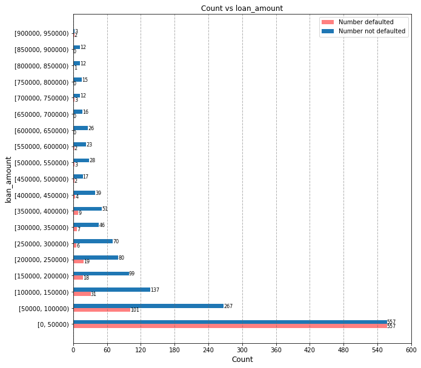

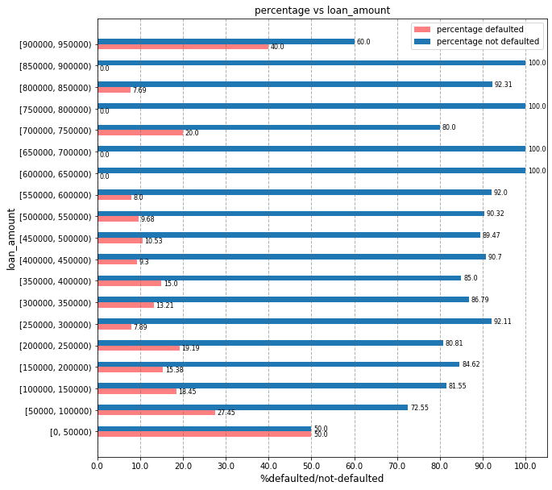

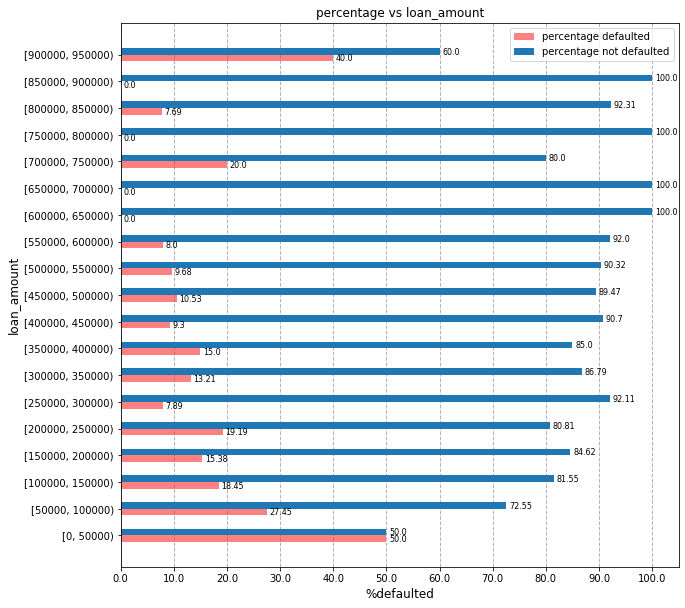

```python
bins = np.arange(0,10**6,5*10**4)
plot_hist1(data,'loan_amount',bins,(10,10),min(bins),max(bins))
#plot_hist1(data,)
```

```python
data.loc[(data['loan_amount']>=150000) & (data['loan_amount']<200000)]['default_status'].sum()
```

```
18
```

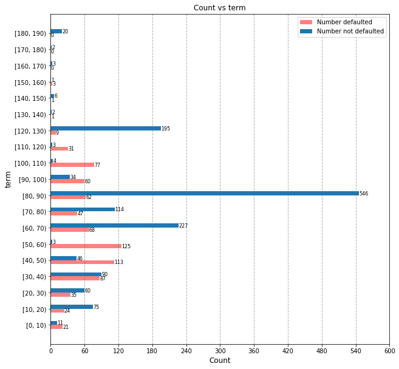

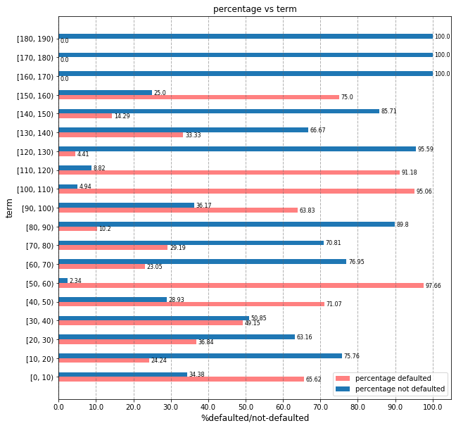

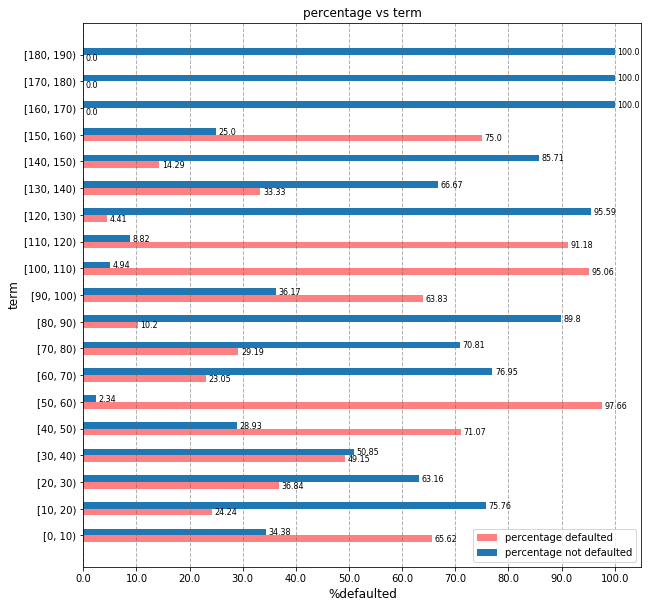

```python
bins = np.arange(0,200,10)
plot_hist1(data,'term',bins,(10,10),min(bins),max(bins))
```

#### Insured Amount vs. Default Rate

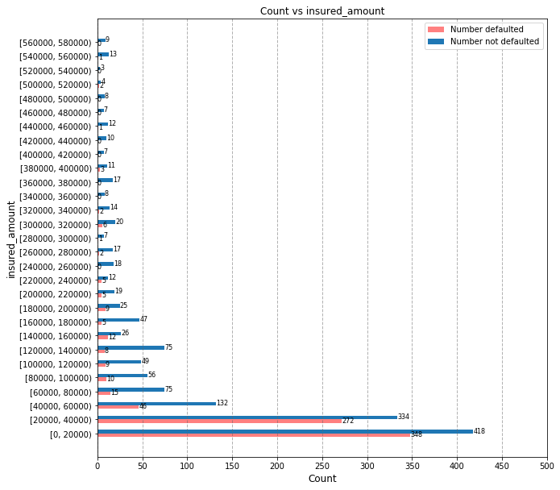

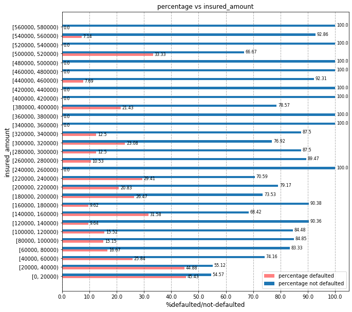

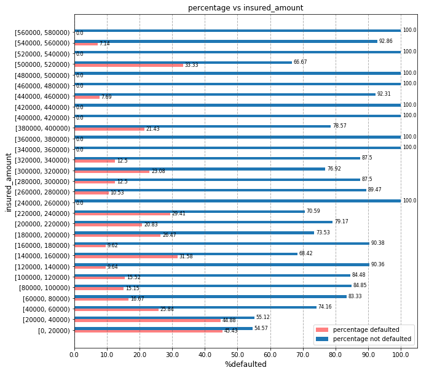

```python
bins = np.arange(0,6*10**5,2*10**4)
plot_hist1(data,'insured_amount',bins,(10,10),min(bins),max(bins))
```

```python
data.loc[(data['insured_amount']>=400000) & (data['insured_amount']<600000)]['default_status'].sum()
```

```
4
```

#### term vs Default Rate

The default rates appear to be sporadically related to loan terms. One cannot draw any conclusive relationship

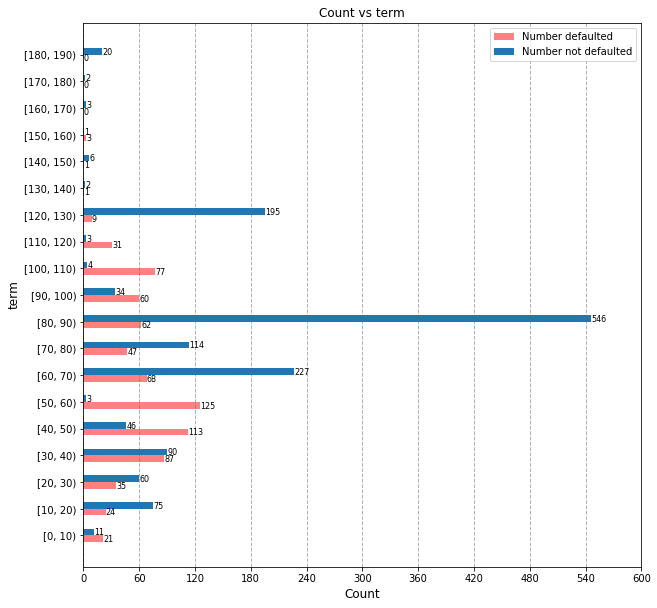

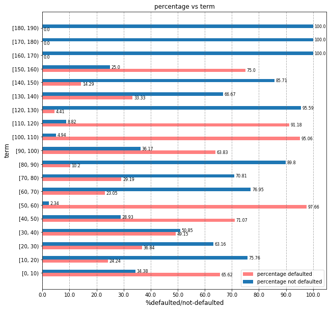

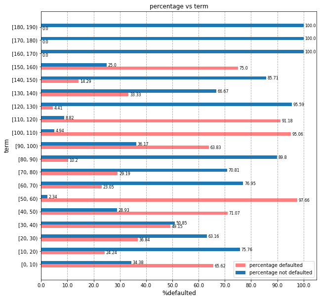

```python
bins = np.arange(0,200,10)
plot_hist1(data,'term',bins,(10,10),min(bins),max(bins))
```

```python
data.loc[(data['term']>=10) & (data['term']<20)]['default_status'].sum()
```

```
24
```

#### Employee Count Vs. Default Rate

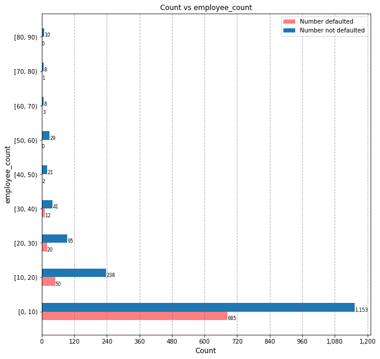

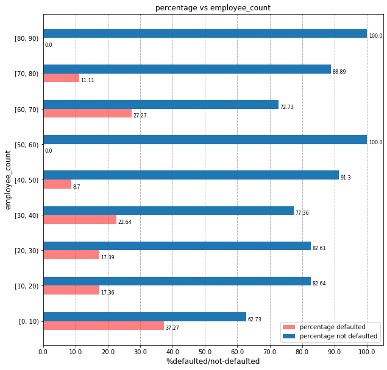

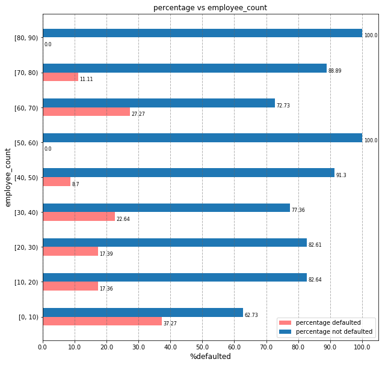

```python
bins = np.arange(0,100,10)
plot_hist1(data,'employee_count',bins,(10,10),min(bins),max(bins))
```

```python
data.loc[(data['employee_count']>=10) & (data['employee_count']<20)]['default_status'].sum()
```

```
50
```

### Bi- Variate Analysis of Categorical Variables

```python
#x = 'brand_department'
def plot_discrete_histogram(data,x,bins0,s):
    #x = 'state'
    def percen(i):
        return(float("{0:.2f}".format(100*i)))
    bins = np.linspace(0,100,num =len(bins0))
    data['locator'] = data[x].apply(lambda x:True if x in bins0 else False)
    data = data.loc[(data['locator'])==True]
    data['ones']=np.ones((data.shape[0]))
    df_dis = data.groupby([x]).agg({'default_status':'sum','ones':'count'}).sort_index(ascending = False)
    df_dis2 = df_dis.reset_index()
    df_dis2['not_defaulted'] = df_dis2['ones'] - df_dis2['default_status']
    df_dis2['avg_default_ratio'] = df_dis2['default_status']/df_dis2['ones']
    df_dis2['avg_non_default_ratio'] = 1 - (df_dis2['default_status']/df_dis2['ones'])
    #-------------------------------------------------------------------------------------
    #print(df_dis2)
    plt.figure(figsize = s)
    ax0 = plt.axes()
    bars1 = np.array(df_dis2['avg_default_ratio'])
    bars2 = np.array(df_dis2['avg_non_default_ratio'])
    bars4 = np.hstack((bars1,bars2))
    bars5 = [percen(i) for i in bars4]

    height = 0.25*(bins[1] - bins[0])
    midpoints = [i+0.5*height for i in bins]
    r1 = [i- 0.5*height for i in midpoints ]
    #print(len(bins),len(midpoints),len(r1),'*****')
    r2 = [i + 0.5*height for i in midpoints]
    r4 = r1 +r2
    labels = np.array(df_dis2[x])
    #print(len(r1),len(bars1))
    plt.barh(r1, bars1,height = height,color = (1,0.5,0.5,1),label ='percentage defaulted')
    #---------------------------------------------------------------------------------------------------
    plt.barh(r2, bars2,height = height,label ='percentage not defaulted')
    plt.xlabel('Percentage',fontsize = 12)
    plt.ylabel(x,fontsize = 12)
    plt.yticks(midpoints,labels)
    plt.title('Percentage vs '+x)
    a1 = np.linspace(0,1,11)
    plt.xticks(a1,[percen(i) for i in a1])
    for i in range(len(r4)):
        plt.text(y = r4[i]-0.5*height , x = bars4[i]+0, s = bars5[i], size = 8)
    plt.grid(b=True, which='major', axis='x', color='#666666', linestyle='--', linewidth=1,alpha = 0.5)
    plt.legend()
    plt.show()
```